# Understading classication Red Wines

David Braga

27-05-2019

I evaluated some external options and the Udacity indications with some examples of masses of data. Because of the guidance of the tutor, indicating that it would be very interesting to analyze a set of data that I did not understand so well, I opted for the mass of red wines. This mass has the physiochemical properties of 1599 red wines. The link used data from https://s3.amazonaws.com/udacity-hosted-downloads/ud651/wineQualityReds.csv

I had few experience using language R and apply advanced functions, because this I research, and getted some examples for help me the mount and build my logic, based in fonts, examples from Udacity and others colleagues.

Font 1 : https://github.com/ppkn/udacity-wine Font 2 : In My GitHub, I uploaded the file .HTML from project Daniel Pipkin. https://github.com/davidbraga28/analyzeRedWinesUdacity/blob/master/Projeto_Referencia_GitHub.html

========================================================

## To begin the analysis on red wines, I will first navigate through the information already existing and in order to understand which variables may be relevant.

## Structure DataFrame

```
## 'data.frame':    1599 obs. of  13 variables:
##  $ X                   : int  1 2 3 4 5 6 7 8 9 10 ...
##  $ fixed.acidity       : num  7.4 7.8 7.8 11.2 7.4 7.4 7.9 7.3 7.8 7.5 ...
##  $ volatile.acidity    : num  0.7 0.88 0.76 0.28 0.7 0.66 0.6 0.65 0.58 0.5 ...
##  $ citric.acid         : num  0 0 0.04 0.56 0 0 0.06 0 0.02 0.36 ...
##  $ residual.sugar      : num  1.9 2.6 2.3 1.9 1.9 1.8 1.6 1.2 2 6.1 ...
##  $ chlorides           : num  0.076 0.098 0.092 0.075 0.076 0.075 0.069 0.065 0.073 0.071 ...
##  $ free.sulfur.dioxide : num  11 25 15 17 11 13 15 15 9 17 ...
##  $ total.sulfur.dioxide: num  34 67 54 60 34 40 59 21 18 102 ...
##  $ density             : num  0.998 0.997 0.997 0.998 0.998 ...
##  $ pH                  : num  3.51 3.2 3.26 3.16 3.51 3.51 3.3 3.39 3.36 3.35 ...
##  $ sulphates           : num  0.56 0.68 0.65 0.58 0.56 0.56 0.46 0.47 0.57 0.8 ...
##  $ alcohol             : num  9.4 9.8 9.8 9.8 9.4 9.4 9.4 10 9.5 10.5 ...
##  $ quality             : int  5 5 5 6 5 5 5 7 7 5 ...
```

## Summarize DataFrame

```
##        X          fixed.acidity   volatile.acidity  citric.acid
##  Min.   :   1.0   Min.   : 4.60   Min.   :0.1200   Min.   :0.000
##  1st Qu.: 400.5   1st Qu.: 7.10   1st Qu.:0.3900   1st Qu.:0.090
##  Median : 800.0   Median : 7.90   Median :0.5200   Median :0.260
##  Mean   : 800.0   Mean   : 8.32   Mean   :0.5278   Mean   :0.271
##  3rd Qu.:1199.5   3rd Qu.: 9.20   3rd Qu.:0.6400   3rd Qu.:0.420
##  Max.   :1599.0   Max.   :15.90   Max.   :1.5800   Max.   :1.000
##  residual.sugar     chlorides       free.sulfur.dioxide
##  Min.   : 0.900   Min.   :0.01200   Min.   : 1.00
##  1st Qu.: 1.900   1st Qu.:0.07000   1st Qu.: 7.00
##  Median : 2.200   Median :0.07900   Median :14.00
##  Mean   : 2.539   Mean   :0.08747   Mean   :15.87
##  3rd Qu.: 2.600   3rd Qu.:0.09000   3rd Qu.:21.00
##  Max.   :15.500   Max.   :0.61100   Max.   :72.00
##  total.sulfur.dioxide    density             pH          sulphates
##  Min.   :  6.00       Min.   :0.9901   Min.   :2.740   Min.   :0.3300
##  1st Qu.: 22.00       1st Qu.:0.9956   1st Qu.:3.210   1st Qu.:0.5500
##  Median : 38.00       Median :0.9968   Median :3.310   Median :0.6200
##  Mean   : 46.47       Mean   :0.9967   Mean   :3.311   Mean   :0.6581
##  3rd Qu.: 62.00       3rd Qu.:0.9978   3rd Qu.:3.400   3rd Qu.:0.7300
##  Max.   :289.00       Max.   :1.0037   Max.   :4.010   Max.   :2.0000
##     alcohol         quality
##  Min.   : 8.40   Min.   :3.000
##  1st Qu.: 9.50   1st Qu.:5.000
##  Median :10.20   Median :6.000
##  Mean   :10.42   Mean   :5.636
##  3rd Qu.:11.10   3rd Qu.:6.000
##  Max.   :14.90   Max.   :8.000
```

# Unvariables Plots

My initial idea is to visualize the variable rating in order for understand them.

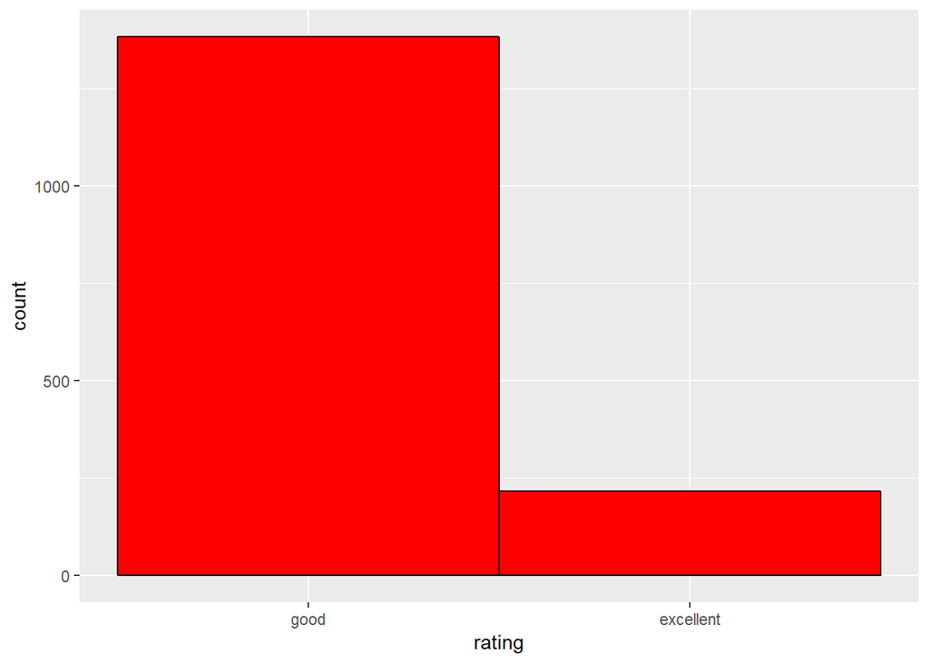

For best understing I researched and read about Red Wine and your feature. On link http://vidaevinho.com/estilos-de-vinho-2/ I found some informations where help me know what mapper and correlate.

How the base already had many indicators, I don’t needed to correlate 2 or more variables.

I ploted the informations from 6 features for analyse.

The First feature was acidity:

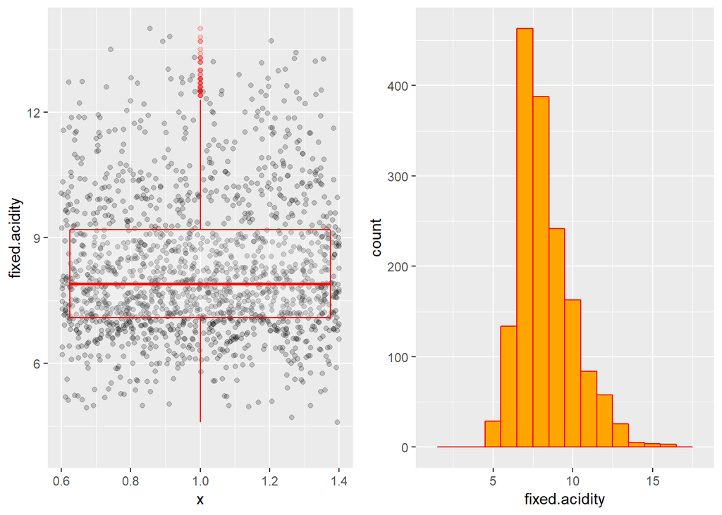

The second feature was citricity, where show peaks between 0.2 and 0.3:

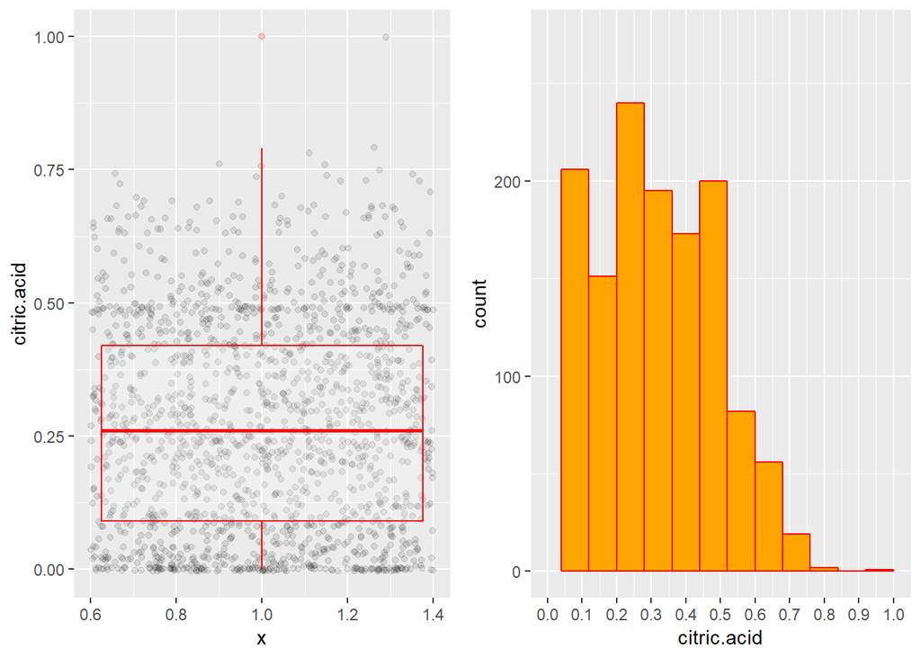

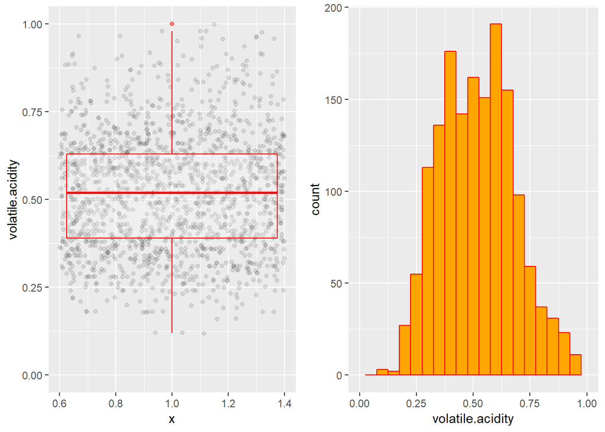

Validating threeth feature, sugar:

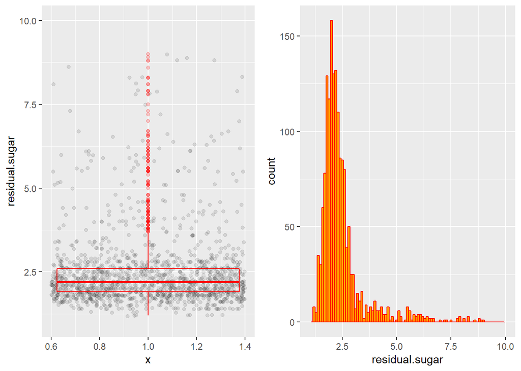

Validating fourth feature, body or density:

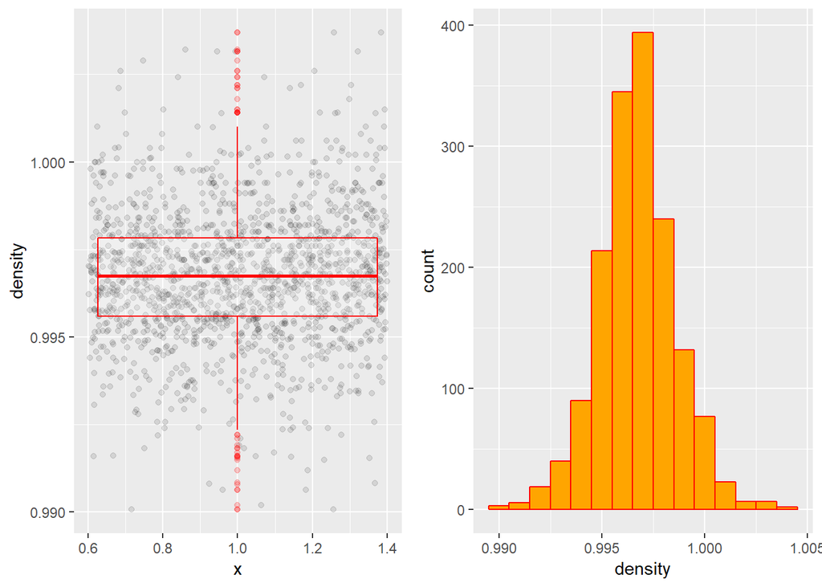

Validating fiveth feature, Ph:

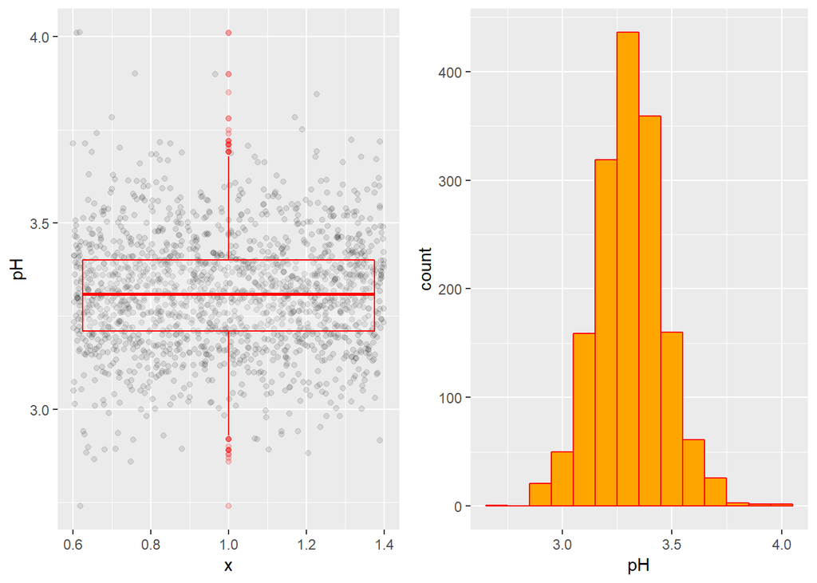

Validating sixth feature, alcohol, it has relatively less outliers, was possbile found biggest peaks and distribution.

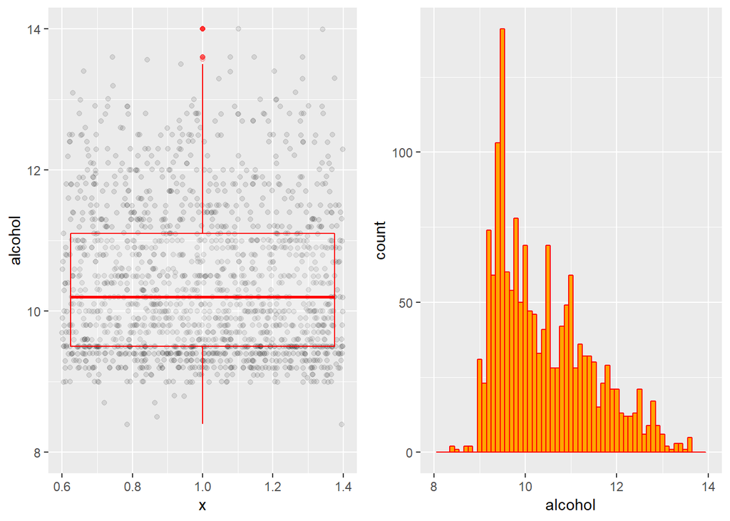

# Análise Univariada

### Quais são os principais atributos de interesse deste conjunto de dados?

My focused was about Rating, where search to classifier for result quality of wine.

### Quais outros atributos você acha que podem lhe auxiliar na investigação destes atributos de interesse?

Following my previous logic, I think that six features help me on mapping. Acidity, Citricity, Sugar, Density, Ph and Alcohol.

### Dos atributos investigados, distribuições incomuns foram encontradas? Você aplicou operações nos dados para limpá-los, ajustá-los ou mudar a forma dos dados? Se sim, por quê?

I read about some tecniches, I tryed others plots, but in my understing, the BoxPlot and histogram resolved without many adjusts. I followed some links how:

https://rstudio-pubs-static.s3.amazonaws.com/258276_7dee24b4a1474558a0f8675db6609d2b.html

# Seção de Gráficos Bivariados

How language R, is not my deep knowledge, I researched some sobjects in google. I Found the link: https://github.com/ppkn/udacity-wine I read the article and project, viewed your file .HTML, and used for next steps.

Now I removed the columns, x and rating, for apply method mutate and analyse in friendly format.

```r
table_wines <- cor(
  wineRed %>%
    dplyr::select(-X) %>%
    dplyr::select(-rating) %>%
    mutate(
      quality = as.numeric(quality)
    )
)
emphasize.strong.cells(which(abs(table_wines) > .3 & table_wines != 1, arr.ind = TRUE))
pandoc.table(table_wines)
```

```
##
## ---------------------------------------------------------------------------
##           &nbsp;            fixed.acidity   volatile.acidity   citric.acid
## -------------------------- --------------- ------------------ -------------
##     **fixed.acidity**             1             -0.2561        **0.6717**
##
##    **volatile.acidity**        -0.2561             1           **-0.5525**
##
##      **citric.acid**         **0.6717**       **-0.5525**           1
##
##     **residual.sugar**         0.1148           0.001918         0.1436
##
##       **chlorides**            0.09371           0.0613          0.2038
##
##  **free.sulfur.dioxide**       -0.1538          -0.0105         -0.06098
##
##  **total.sulfur.dioxide**      -0.1132          0.07647          0.03553
##
##        **density**            **0.668**         0.02203        **0.3649**
##
##           **pH**             **-0.683**          0.2349        **-0.5419**
##
##       **sulphates**             0.183            -0.261        **0.3128**
##
##        **alcohol**            -0.06167          -0.2023          0.1099
##
##        **quality**             0.1241         **-0.3906**        0.2264
## ---------------------------------------------------------------------------
##
## Table: Table continues below
##
##
## ------------------------------------------------------------------------------
##           &nbsp;            residual.sugar   chlorides    free.sulfur.dioxide
## -------------------------- ---------------- ------------ ---------------------
##     **fixed.acidity**           0.1148        0.09371           -0.1538
##
##    **volatile.acidity**        0.001918        0.0613           -0.0105
##
##      **citric.acid**            0.1436         0.2038          -0.06098
```

[output cut: 66 more lines]

```
##
##  **free.sulfur.dioxide**     0.05166      -0.06941      -0.05066
##
##  **total.sulfur.dioxide**    0.04295       -0.2057       -0.1851
##
##        **density**            0.1485     **-0.4962**     -0.1749
##
##           **pH**             -0.1966       0.2056       -0.05773
##
##       **sulphates**             1          0.09359       0.2514
##
##        **alcohol**           0.09359          1        **0.4762**
##
##        **quality**            0.2514     **0.4762**         1
## -------------------------------------------------------------------
```

After the visualizations, I noticed some variations that can change some values.

PH, because of your relation direct on acidity where can to impact others features, density and alcohol.

For undesting, I ploted all features in box plots summarized.

# FIXED.ACIDITY

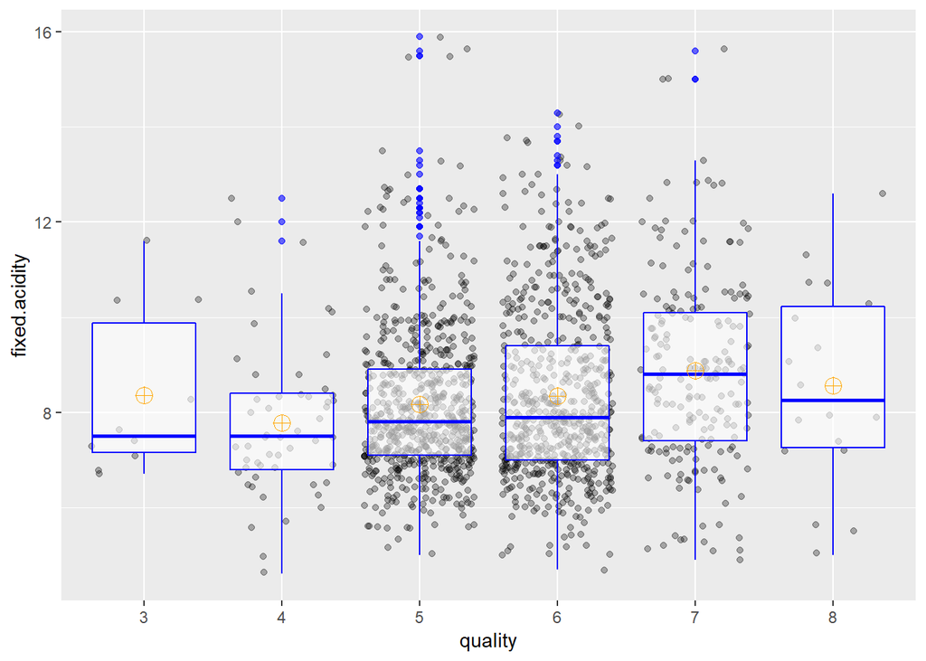

# VOLATILE.ACIDITY

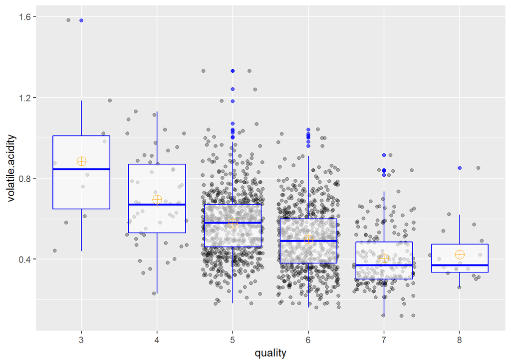

# CITRIC.ACID

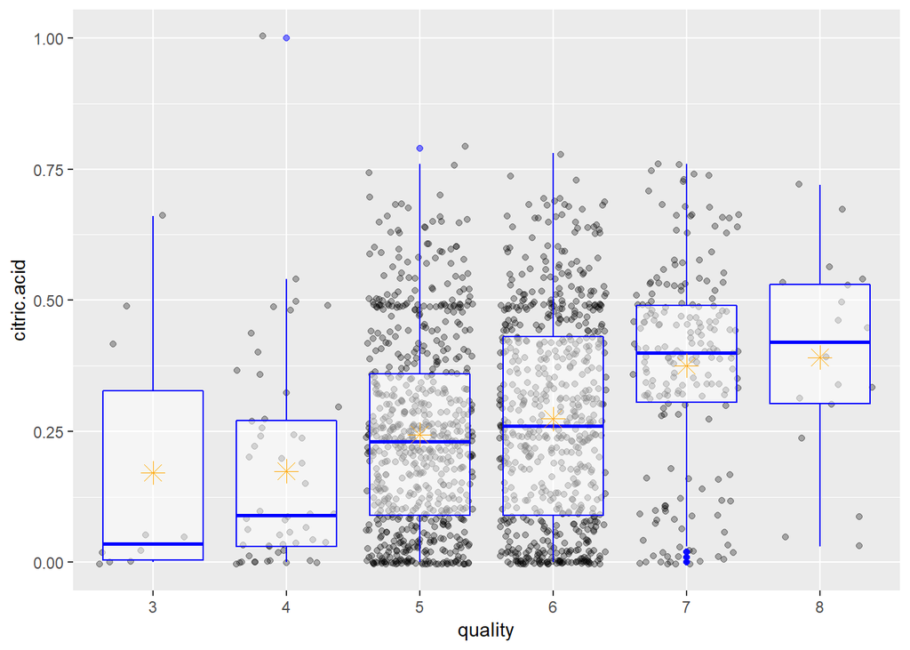

# RESIDUAL.SUGAR

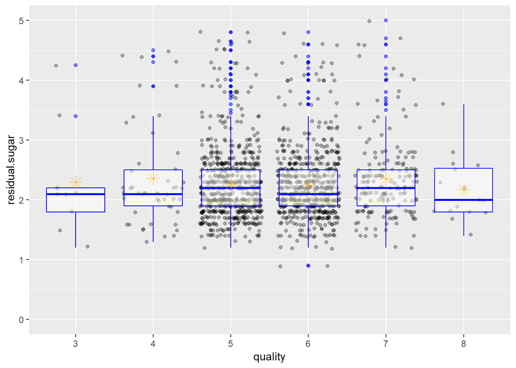

# DENSITY

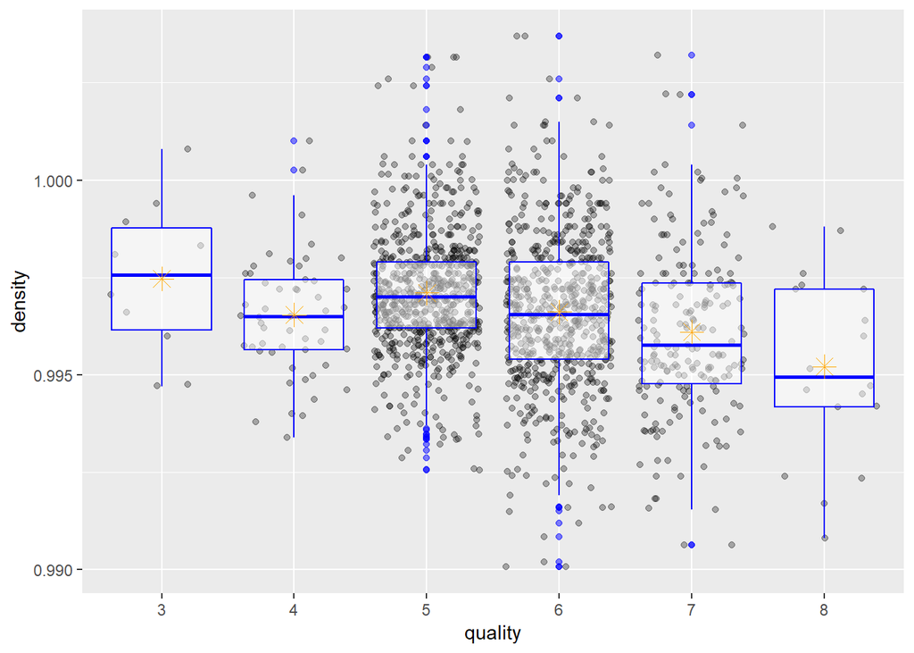

# PH

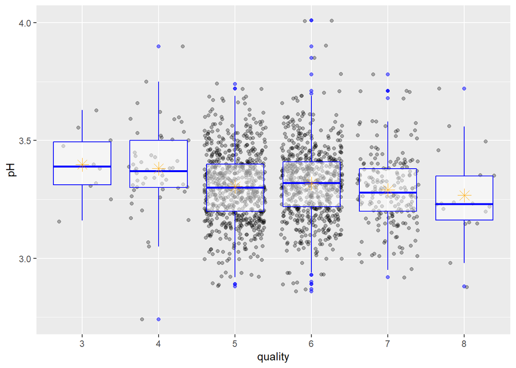

Now, I saw some things about strong influence of PH in others variables. I apply scale for mapper your strongest oscilations. Using Log for trace the variance:

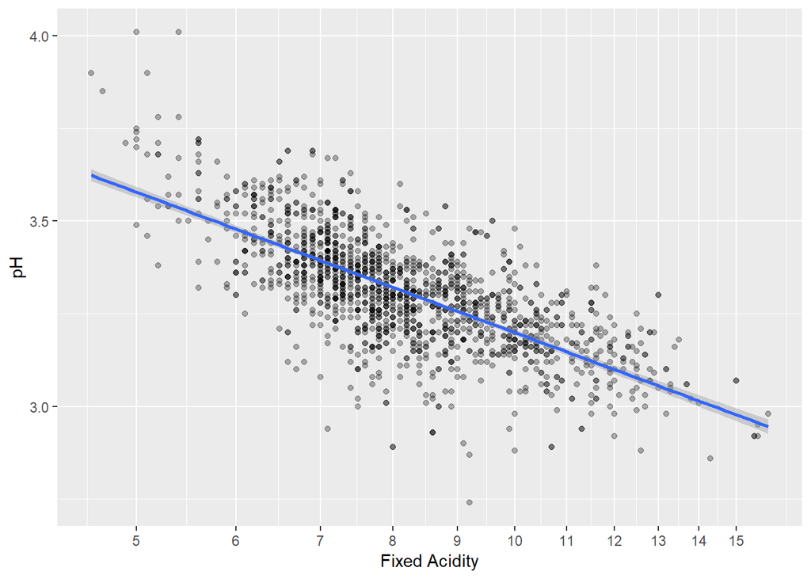

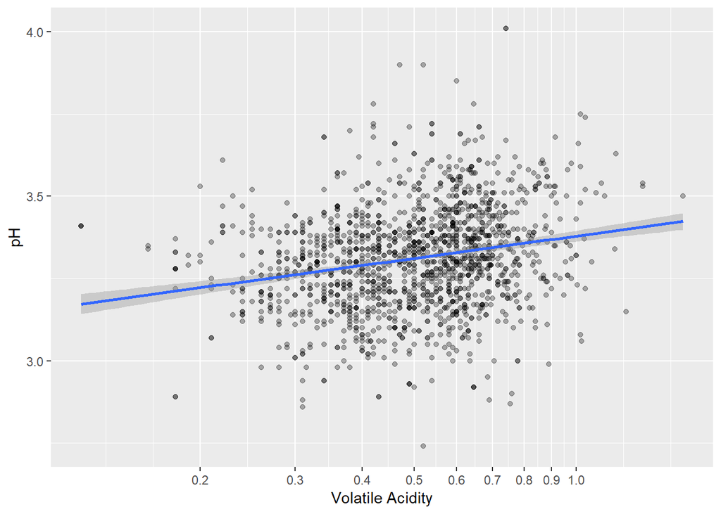

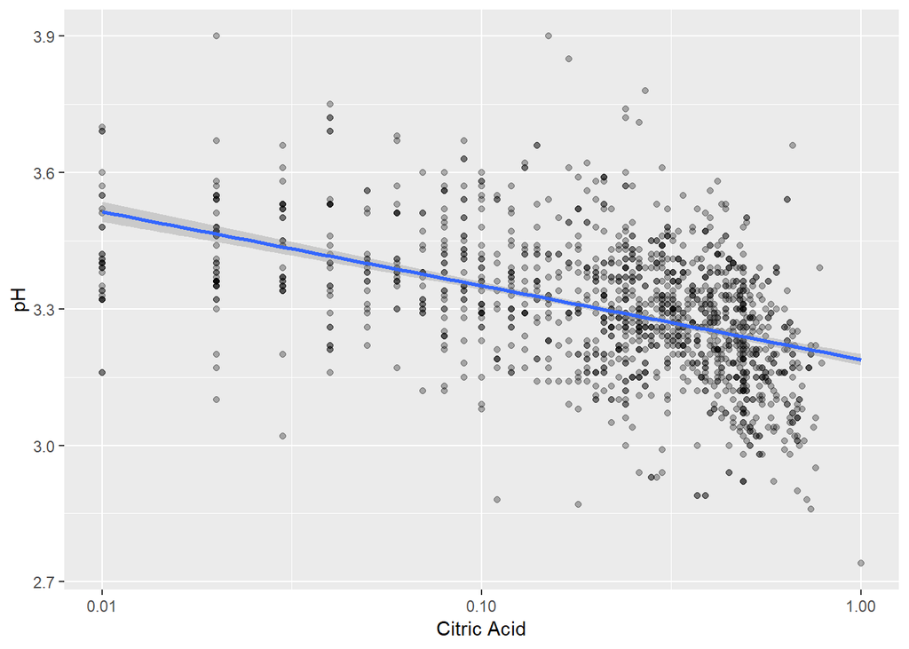

In summary, the greatest influence is that of pH and its influence with acidity is the one that was the most varuation. Consequently the lower the pH, the more acid the wine can be.

# Análise Bivariada

### Você observou algum relacionamento interessante entre os outros atributos (os que não são de interesse)?

I thougth that sugar was more strongest feature, but sugar did not the problem. I needed to pay attention to density and pH.

### Qual foi o relacionamento mais forte encontrado?

# Seção de Gráficos Multivariados

# Análise Multivariada

After, analyse about pH, started to test the alcohol, because in my studies, quantity can influence density that influence quality directly. I ploted a graph mapper density and your co relation in the quality.

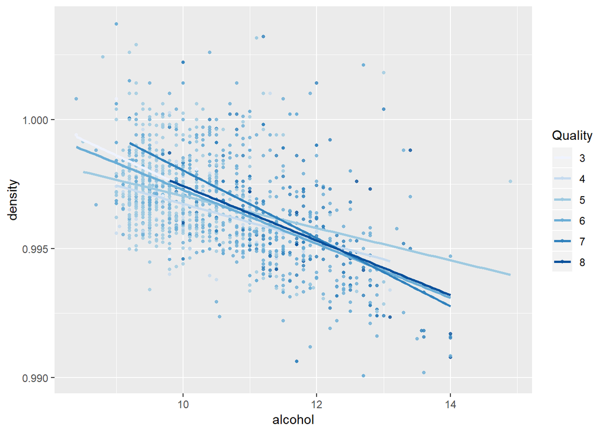

In the graph for density, not stayed clear the real influence about quality, for undestanding, detailed added the property sulphates, for read more informations.

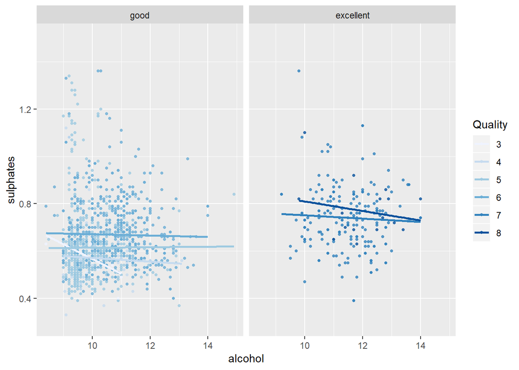

So, the few feature, but important feature is the co relation between alcohol and sulphates, the graph showed that wines with more quality had most indexes of sulphates.

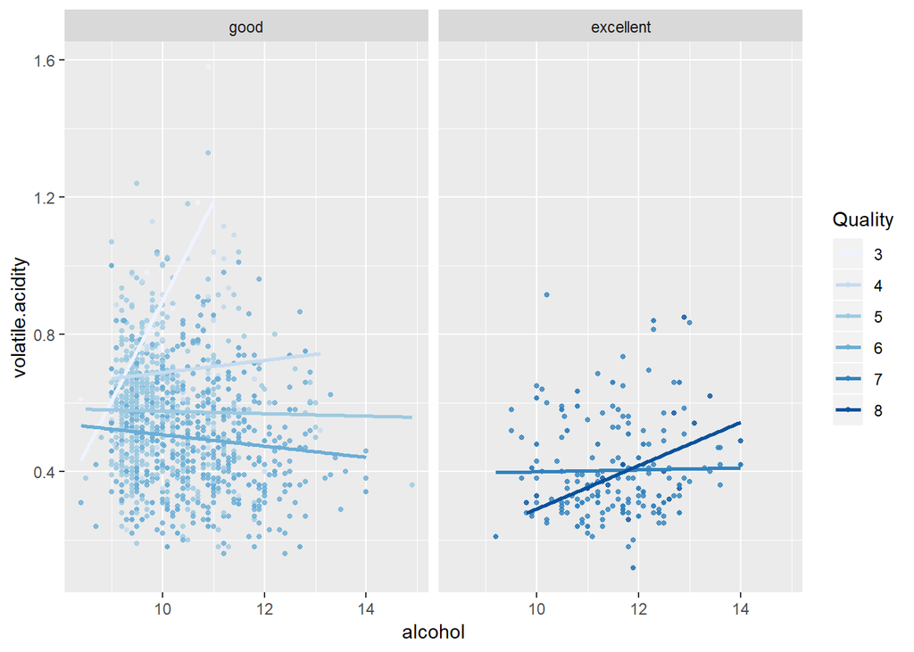

So, Volatile acid has the opposite effect. With less concentration of volatile acid and higher concentration of alcohol seems to produce better wines.

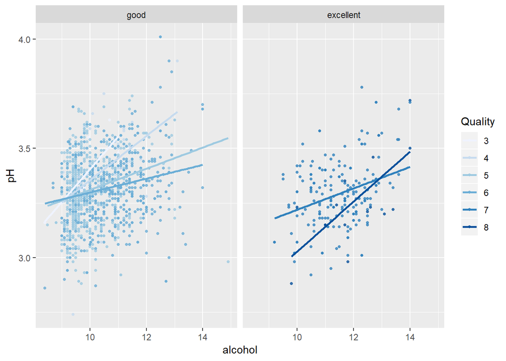

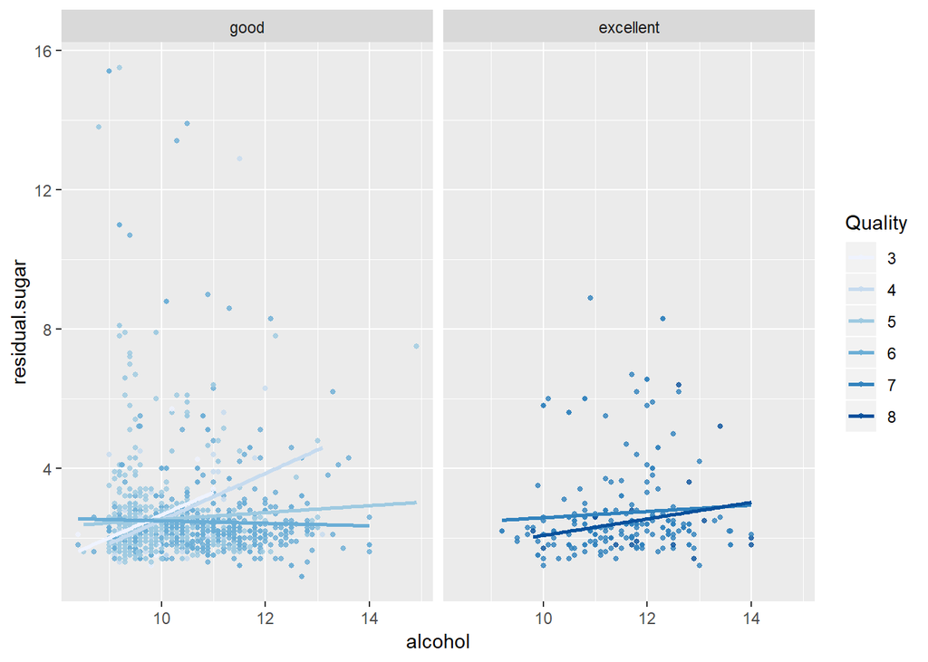

The feature sugar, demonstrated how really not has influence about quality. No changes.

Finishing, below, I ploted using ACID, where is the most evidence and feature that showed how better wines so produced.

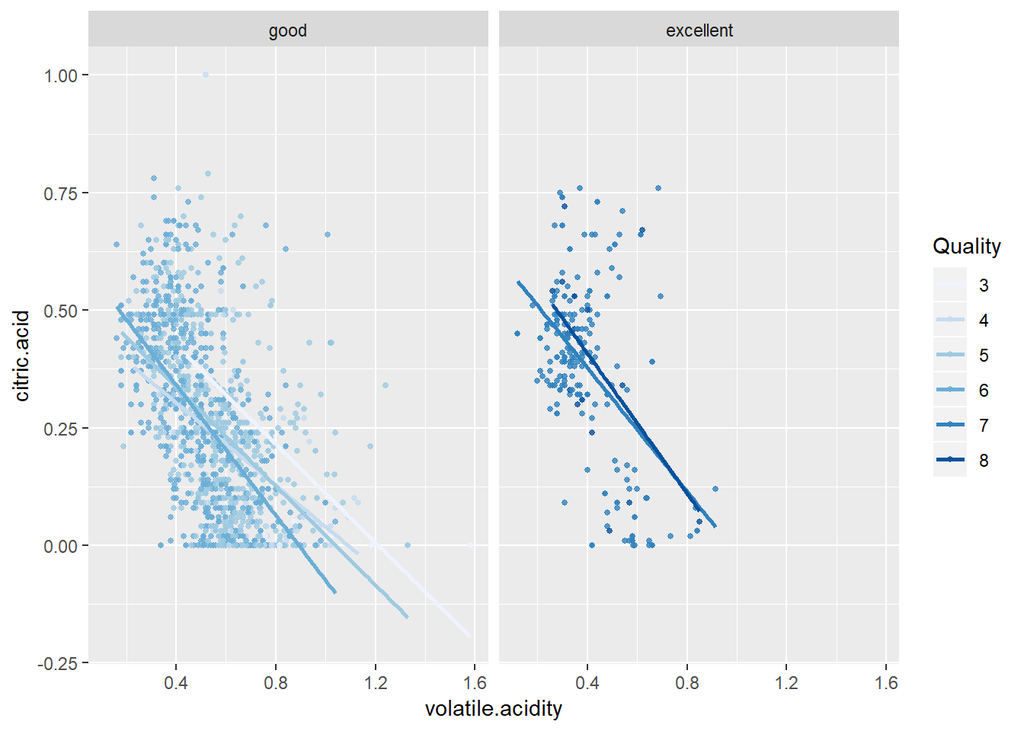

Higher Citric Acid and low Volatile Acid produce better Wines.

### Interações surpreendentes e/ou interessantes foram encontradas entre os atributos?

For my surprise, I always thougth that sugar was the higher component from wine, really modife the type of wine and your features. But, sugar haven’t nothing influence in quality directly. Obviously speaking in quantities correct.

### OPCIONAL: Modelos foram criados usando este conjunto de dados? Discuta sobre os pontos fortes e as limitações do seu modelo.

# Gráficos Finais e Sumário

### Description One

In my understanding the alcohol and sulphates had most influence in the analyzes. The graph below, shows gradually that the greater the balance of alcohol and sulfates the better the direct quality of the wine.

### Plot 1

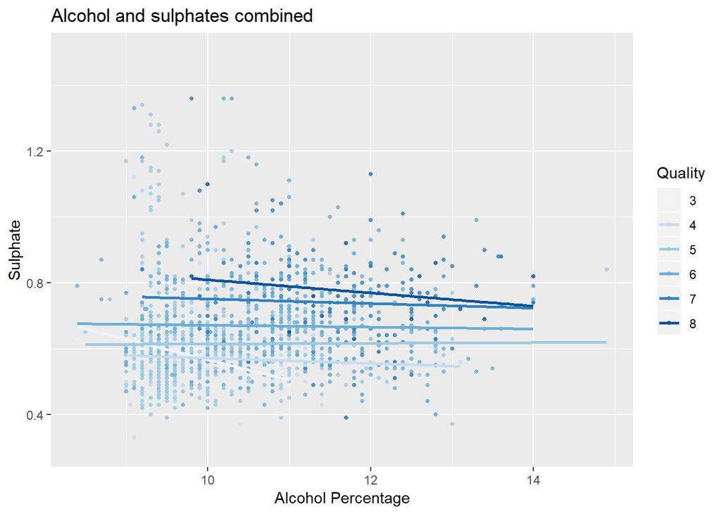

### Description Two

The next plot, showed the distribuition of alcohol into some features, and in isolation the alcohol change strongest and directly the quality of wines.

### Plot 2

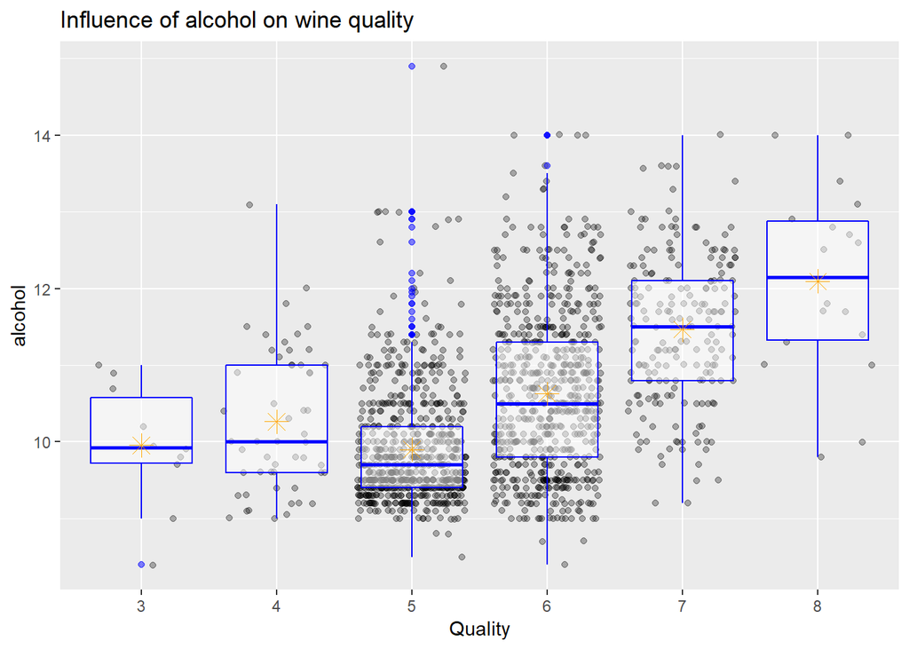

### Plot 3

[figure not shown]

# Reflexão

My main focus was to know the variables that exist for quality classification. There are no items that could be of greater interest, such as that they had greater influence without classification results.

Following some indications and separating over the wine analysis, the differences in quality variables for the univariate relationships between them, then within their efforts in comparison to the results, where they were able to make analogies in realistic and comparative thoughts with some external studies. These were the ones that altered the quality of the wine and the percentages of alcohol, sulfate and acid and thus their correlations consequently.

I had a hard time not knowing the resources of the “R” language. I also had difficulties in using the information contained in a larger part of the data are in average, making it difficult to access not to emphasize the analyzes.

In short, I was able to understand the data and a structure of the dataset, I was unable to produce an image that was not functional, but I believe it was the process of analysis and the results of the study and work processes.I liked very much of experience, really leaned of course.

Thank you Udacity!!